# Quantum Computing for Quantum Chemistry

#### Unitary time evolution of Pauli operators

A single Pauli string $\hat P$ is both Hermitian and unitary, so its time-evolution operator $e^{-it\hat P}$ is unitary and can be implemented as a circuit.

For $\hat P=\hat Z_1\otimes \hat Z_2\otimes\cdots\otimes \hat Z_M$, the unitary $e^{-it\hat P}$ can be implemented by computing the parity of the $M$ qubits with a CNOT ladder, applying a single $R_z(2t)$ rotation to one qubit, and then uncomputing the parity [1]. This is verified mathematically below.

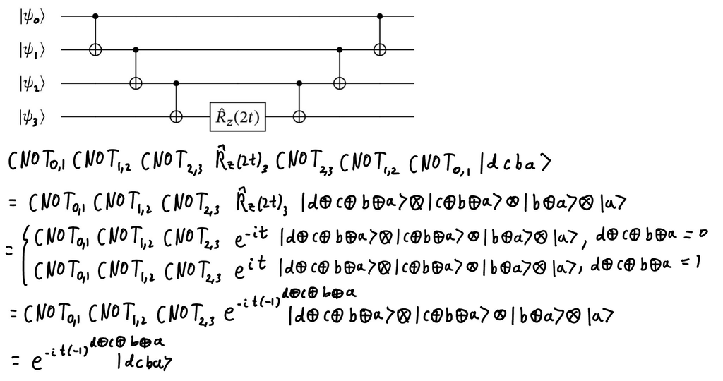

```python
Image('3_3.jpg')
```

If $\hat P$ contains $\hat X_p$ or $\hat Y_p$ factors, each is first conjugated into $\hat Z_p$ using single-qubit basis changes, $$ \hat X_p = \hat H_p \hat Z_p \hat H_p,\qquad \hat Y_p = (\hat S_p \hat H_p^\dagger)\hat Z_p(\hat H_p \hat S_p^\dagger), $$ after which the same parity - $R_z(2t)$ - uncompute pattern applies [1].

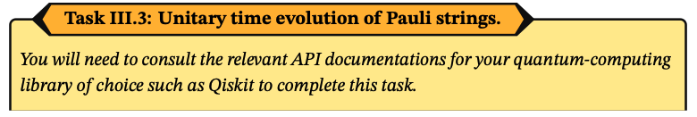

```python
Image('3_3a.png')
```

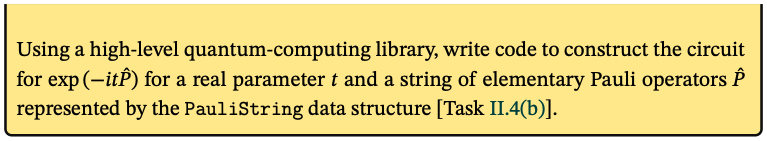

```python
Image('3_3b.png')
```

```python
def exp_it(ps, t, num_qubits):
    qop = ps.to_openfermion()
    terms = list(qop.terms.items())

    term, coeff = terms[0]
    qc = QuantumCircuit(num_qubits)

    basis_changes = []

    #involved qubits (non identity)
    involved = [p for p, n in sorted(term, key=lambda x: x[0])]

    #keep to uncompute
    for p, op in sorted(term, key=lambda x: x[0]):
        #sort by qubit index
        if op == "X":
            qc.h(p)
            basis_changes.append((p, "X"))
        elif op == "Y":
            qc.sdg(p) #notes have conjugation order incorrect
            qc.h(p)
            basis_changes.append((p, "Y"))
        elif op == "Z":
            basis_changes.append((p, "Z"))

    # cnot over involved qubits
    for i in range(len(involved) - 1):
        qc.cx(involved[i], involved[i+1])

    # Phase rotation
    qc.rz(2.0 * t, involved[-1])

    # uncompute
    for i in reversed(range(len(involved) - 1)):
        qc.cx(involved[i], involved[i+1])

    #undo basis changes
    for p, op in reversed(basis_changes):
        if op == "X":
            qc.h(p)
        elif op == "Y":
            qc.h(p)
            qc.s(p)
        elif op == "Z":
            pass

    return qc
```

Check if the circuit for $\exp[-it(\hat Z_1 \otimes\hat X_2 \otimes\hat Y_3 \otimes\hat Z_4)]$ is correct.

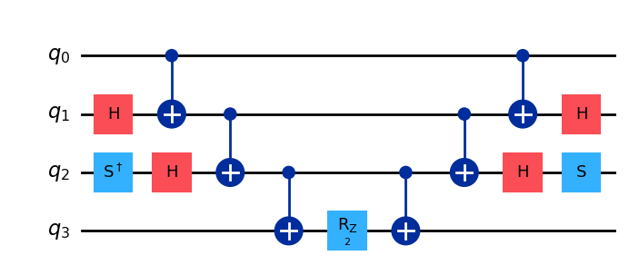

```python
ps = PauliString([(0,"Z"),(1,"X"), (2,"Y"), (3,"Z")])
t = 1
qc = exp_it(ps, t, num_qubits=4)
qc.draw("mpl")
```

Circuit as expected.

See if the Identity is correctly accounted for, with $\exp[-it(\hat Z_1 \otimes\hat I_2 \otimes\hat Y_3 \otimes\hat Z_4)]$.

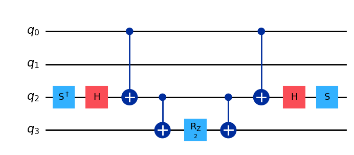

```python
ps1 = PauliString([(0,"Z"),(1,"I"), (2,"Y"), (3,"Z")])
t = 1
qc = exp_it(ps1, t, num_qubits=4)
qc.draw("mpl")
```

Answer as expected, without CNOT on qubit 1.

#### Trotterisation

A general qubit operator is a sum of $K$ Pauli strings, $$ \hat Q=\sum_{k=0}^{K-1} c_k \hat P_k, $$ which is Hermitian but not unitary. Quantum simulation requires the unitary time evolution $e^{-it\hat Q}$, but since the Pauli string terms $\hat P_k$ do not necessarily commute, $$ e^{-it\sum_k c_k\hat P_k}\neq \prod_k e^{-it c_k \hat P_k}. $$ The Trotter-Suzuki formulas approximate $e^{-it\hat Q}$ as follows.

First order with Trotter number $r$: $$ e^{-it\hat Q}= \left[\prod_{k=0}^{K-1}\exp\left(-i\frac{t}{r}c_k\hat P_k\right)\right]^r+ \mathcal{O}(t^2/r). $$ Second order Trotter-Suzuki: $$ e^{-it\hat Q}= \left[\prod_{k=0}^{K-1}\exp\left(-i\frac{t}{2r}c_k\hat P_k\right) \prod_{k=0}^{K-1}\exp\left(-i\frac{t}{2r}c_{K-k-1}\hat P_{K-k-1}\right)\right]^r+ \mathcal{O}(t^3/r^2). $$ Increasing $r$ reduces the approximation error but increases circuit depth [1].

The indexing for the second order Trotter-Suzuki formula is verified below, noting that for this example the first $q$ has index $1$, like in the manual.

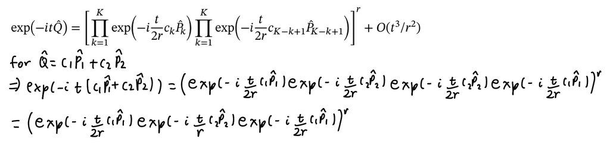

```python
Image('3_4.jpg')
```

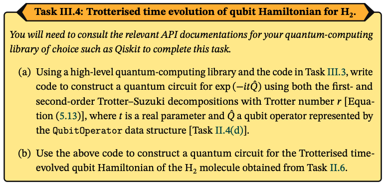

```python
Image('3_4.png')
```

**(a)**

```python
def trotter_first_order(Q, t, r, num_qubits):
    qc = QuantumCircuit(num_qubits)

    terms = []
    for term, coeff in Q.to_openfermion().terms.items():
        ps = PauliString(list(term))
        terms.append((coeff, ps))
    terms.sort(key=lambda x: str(x[1])) #deterministic term order


    dt = t / r
    for _ in range(r):
        for ck, Pk in terms:
            qc.compose(exp_it(Pk, (dt * ck).real, num_qubits), inplace=True)
            # modify rather than new circuit
    return qc

def trotter_second_order(Q, t, r, num_qubits):
    qc = QuantumCircuit(num_qubits)
    terms = []
    for term, coeff in Q.to_openfermion().terms.items():
        ps = PauliString(list(term))
        terms.append((coeff, ps))

    terms.sort(key=lambda x: str(x[1]))
    dt = t / r

    for _ in range(r):
        for ck, Pk in terms:
            qc.compose(exp_it(Pk, (dt * ck/2).real, num_qubits), inplace=True)

        for ck, Pk in reversed(terms):
            qc.compose(exp_it(Pk, (dt * ck/2).real, num_qubits), inplace=True)

    return qc
```

Confirm whether the circuit from III.3 is correctly reproduced.

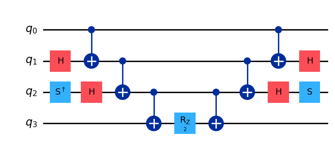

```python
ps = PauliString([(0,"Z"),(1,"X"), (2,"Y"), (3,"Z")])
t = 1
qc=trotter_first_order(ps,t,1,4)
qc.draw("mpl")
```

Circuit as desired. Now confirm if second order is correct.

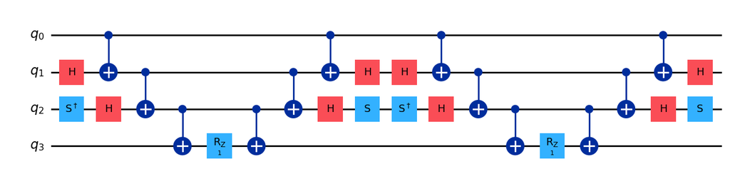

```python
qc=trotter_second_order(ps,t,1,4)
qc.draw("mpl")
```

Circuit as desired.

**(b)**

$H_2$ molecule.

```python
#useful for final module
def ps_convert(H_q):
    ops = []
    for term, coeff in H_q._qop.terms.items():
        if term:
            ops.append((coeff.real, PauliString(list(term))))
    return QubitOperator(ops)
H2_q=ps_convert(H_q)
print(H2_q)
```

```
-0.049197645871367546 [X0 X1 Y2 Y3] +
0.049197645871367546 [X0 Y1 Y2 X3] +
0.049197645871367546 [Y0 X1 X2 Y3] +
-0.049197645871367546 [Y0 Y1 X2 X3] +
0.13716572937099492 [Z0] +
0.1566006248823794 [Z0 Z1] +
0.10622904490856078 [Z0 Z2] +
0.15542669077992832 [Z0 Z3] +
0.13716572937099483 [Z1] +
0.15542669077992832 [Z1 Z2] +
0.10622904490856078 [Z1 Z3] +
-0.13036292057109045 [Z2] +
0.1632676867356434 [Z2 Z3] +
-0.13036292057109042 [Z3]
```

```
First Order:
```

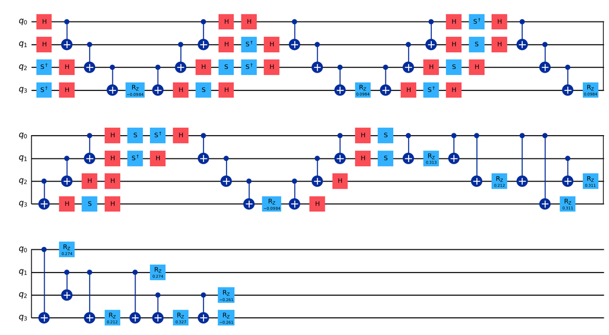

```python
t = 1
r = 1
num_qubits = 4

qc_1st = trotter_first_order(H2_q, t, r, num_qubits)
qc_2nd = trotter_second_order(H2_q, t, r, num_qubits)
print("First Order:")
qc_1st.draw("mpl")
```

All terms appear as expected, but the one body $Z_i$ terms end up at the end because the conversion rebuilds the operator and can change the term insertion order. Since the Pauli terms do not all commute, different orderings correspond to different first order Trotter approximations, with local error $\mathcal{O}(\Delta t^2)$, which is expected. As long as a single ordering is fixed and used consistently, it is meaningful to compare results across runs (noting that different orderings can have different constants in the error).

```
Second Order:
```

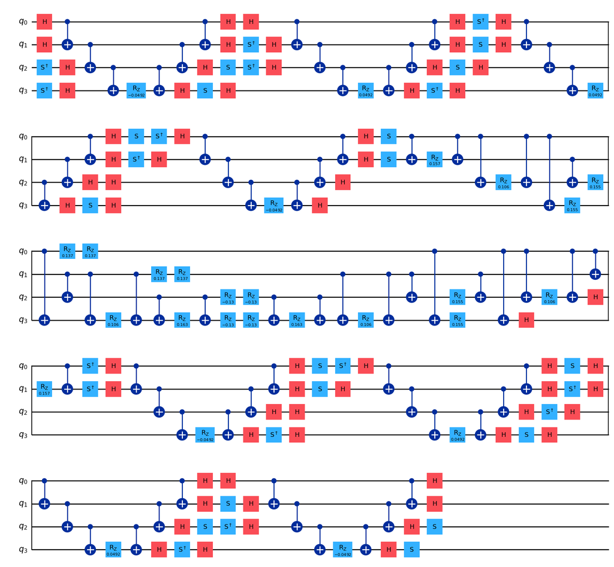

```python
print("Second Order:")
qc_2nd.draw("mpl")
```

### Discussion Questions

*What is the maximum number of qubits that your computer can handle for state- vector simulations? What aspects of your computer (e.g. CPUs or RAM) determine this? How does this answer change if you change the numerical data type of state-vector elements (e.g. single- or double-precision complex numbers)?*

Complex128 is double precision complex and uses 16 bytes per amplitude, and Complex64 is single precision complex and uses 8 bytes per amplitude [7]. My laptop has 24GB (~22.35 GiB) of ram which means with Complex128 I can use 30 qubits $\left(22.35\cdot2^{30}\approx2^{34.48}=16\cdot2^{30.48}\right)$, and with Complex64 I can use 31 qubits $\left(2^{34.48}=8\cdot2^{31.48}\right)$ [8].

*Can you give a bound for the depth of the circuit for $\text{exp}(−it\hat{P})$ in terms of the length of $\hat{P}$?*

Pauli of length $l$ ($l$ non-identity Paulis) has circuit depth that scales linearly in $l$. Parity compute uses $l-1$ CNOT layers, then one $R_z$, then $l-1$ layers to uncompute, worst case $Y$ basis change requires $4$ layers $\Rightarrow\text{depth}\leq2(l-1)+1+4=2l+3$.

*How does the depth of the circuit for $\text{exp}(−it\hat{P})$ vary with the Trotter number $r$? What about the numerical errors arising from the Trotter–Suzuki decompositions? Can you quantify this numerically for a simple $\hat{Q}$?*

For $\hat{Q}=\sum_{k=0}^{K-1}c_k\hat{P}_k$, first order $\text{depth}\approx r\sum_{k=0}^{K-1}\text{depth}\left[\text{exp}(−i\frac{t}{r}c_k\hat{P}_k)\right]\approx r\sum_{k=0}^{K-1}(2l_k+3)$, and for second order, $\text{depth}\approx 2r\sum_{k=0}^{K-1}(2l_k+3)$.

Error scales as shown below, with example $\hat{Q}=\hat{X}_0+\hat{Z}_0$. Noting that if $A$ is Hermitian and has eigenvalue equation $Av_i=\lambda_i v_i$ then $A=V\Lambda V^\dagger$ with $\Lambda=\text{diag}(\lambda_i)$, and $V=[v_1\cdots v_n]$ (for $n$ eigenvectors). This means that $e^{-itA}=e^{-itV\Lambda V^\dagger}=Ve^{-it\Lambda}V^\dagger=V\text{diag}\left(e^{-it\lambda_i}\right)V^\dagger$ (as $V^\dagger V=I$, and $\Lambda$ is diagonal).

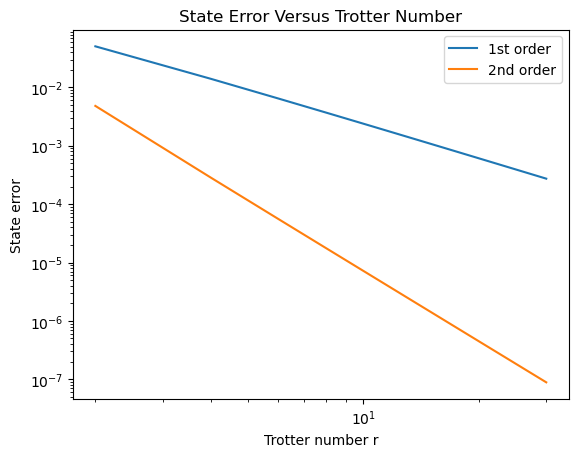

```python
t = 1
rs = np.arange(2, 31, 2)
# exact
evals, evecs = np.linalg.eigh(X +Z)
Ue = evecs @ np.diag(np.exp(-1j * t* evals)) @ evecs.conj().T

# trotterisation
Xps = PauliString([(0,"X")])
Zps = PauliString([(0,"Z")])
Q = QubitOperator([(1.0,Xps), (1.0,Zps)])


psi0 =Statevector.from_label("0")
#input state
err1, err2 = [], []
for r in rs:
    qc1 = trotter_first_order(Q, t,r,num_qubits=1)
    qc2 = trotter_second_order(Q, t,r,num_qubits=1)

    psi1 =psi0.evolve(qc1).data
    psi2 =psi0.evolve(qc2).data

    err1.append(1 -np.abs(np.vdot(Ue @ np.array([1,0],complex), psi1))**2)
    #Ue|0>, inner product of this with psi1
    err2.append(1 -np.abs(np.vdot(Ue @ np.array([1,0],complex), psi2))**2)

plt.loglog(rs, err1, label="1st order")
plt.loglog(rs, err2, label="2nd order")
plt.xlabel("Trotter number r")
plt.ylabel(r"State error")
plt.title("State Error Versus Trotter Number")
plt.legend()
plt.show()
```

First order has global operator error $\mathcal{O}(t^2/r)\Rightarrow$ state infidelity scales as $\approx \mathcal{O}(1/r^2)$ (for fixed $t$), whereas second order has global operator error $\mathcal{O}(t^3/r^2)$ so state infidelity scales as $\approx \mathcal{O}(1/r^4)$. $\Rightarrow$ Expect 1st order to have slope $\approx-2$, and 2nd order to have slope $\approx-4$.

```python
m1, b1 = np.polyfit(np.log(rs), np.log(err1), 1)
m2, b2 = np.polyfit(np.log(rs), np.log(err2), 1)

print("slope (1st order):", m1)
print("slope (2nd order):", m2)
```

```
slope (1st order): -1.9394583122114095
slope (2nd order): -4.0196902494381455
```

Answer as expected.

## Module 3 Logbook

This laboratory focused on simulation in quantum computing, both as classical emulation of quantum circuits and as time evolution implemented with qubits. The first part considered classical state-vector simulation. A computational basis bitstring was mapped to an $M$ index complex tensor representing the full $2^M$ dimensional state. This showed how amplitudes and measurement frequencies are stored and why memory grows exponentially with qubit number.

Single Pauli strings were then applied directly to the state-vector using tensor contractions with the Pauli matrices reproducing simple quantum circuits only using linear algebra. Frequencies obtained from $|V_{i_0i_1\cdots i_{M-1}}|^2$ matched the expected computational basis outcomes, which confirmed that the indexing and contraction logic were correct.

The same tasks were repeated using Qiskit. Circuits were initialized to chosen bitstrings and layers of Pauli gates were appended from a PauliString description. Statevector simulation and shot based sampling with the Aer simulator gave the same results as the manual tensor approach.

The next part considered unitary time evolution under a Pauli string $\exp(-it\hat P)$. Basis changes converted $\hat{X}$ and $\hat{Y}$ operators to $\hat{Z}$, followed by parity accumulation with CNOT ladders, a single $R_z(2t)$ rotation, and uncomputation.

Finally, Trotterisation was used to approximate time evolution generated by a sum of Pauli strings. First and second order Trotter-Suzuki formulas were implemented and applied to the $H_2$ qubit Hamiltonian. Increasing the Trotter number reduced approximation error but increased circuit depth, which would increase hardware noise on current hardware. A one qubit example with $\hat Q = \hat{X}+\hat{Z}$ was used to study the error scaling by comparing Trotterized evolution to the exact solution.

# Part IV

## Obtaining Electronic Energies

#### Quantum phase estimation

The electronic Hamiltonian $\hat H$ is Hermitian but not unitary, so the unitary operator $\hat U(t)=e^{-it\hat H}$ is used instead of $\hat H$ itself. If $\hat H\Psi_j=E_j\Psi_j$, then $\Psi_j$ is also an eigenstate of $\hat U(t)$ with eigenvalue $e^{-itE_j}$, so estimating the phase of $\hat U(t)$ can be used to find the energy $E_j$.

More generally, for a unitary $\hat U$ with $$ \hat U|\Psi_j\rangle = e^{2\pi i\theta_j}|\Psi_j\rangle,\qquad \theta_j\in[0,1), $$ quantum phase estimation (QPE) uses an $n$-qubit estimation register to infer the binary fraction $\theta_j\approx \overline{0.b_1b_2\cdots b_n}\equiv\frac{\overline{\theta}_j}{2^n}, \quad b_i \in \{0,1\}$.

An example for $\theta_j=0.5$ is shown below.

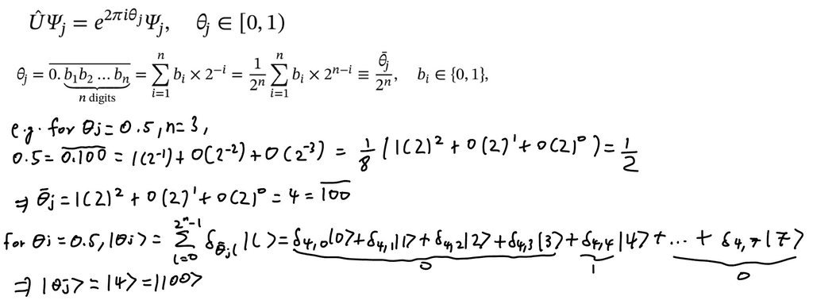

```python
Image('6_a.jpg')
```

The QPE circuit prepares a uniform superposition on the estimation register. Controlled powers $\hat U^{2^m}$ are applied to the state register (initialised as $|\Psi_j\rangle$), controlled on each estimation qubit ($m=0,1,\cdots,n-1$). A $\text{QFT}^{-1}$ is then applied, noting that $\text{QFT}|\theta_j\rangle=\frac{1}{\sqrt{2^n}}\sum_{k=0}^{2^n-1} e^{2\pi i \theta_j k}|k\rangle$. The estimation register then becomes the state $|\theta_j\rangle$.

If the state register is initialised in a guess state $$ |\Psi_{\rm guess}\rangle=\sum_j c_j|\Psi_j\rangle, $$ then an estimate of $\theta_j$ accurate to n binary places is obtained with probability $|c_j|^2$, so good overlap with the desired eigenstate is required [1].

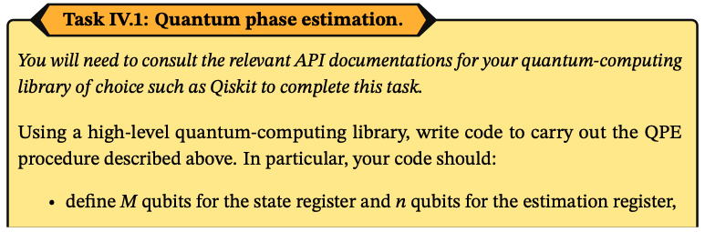

```python
Image('4_1a.png')
```

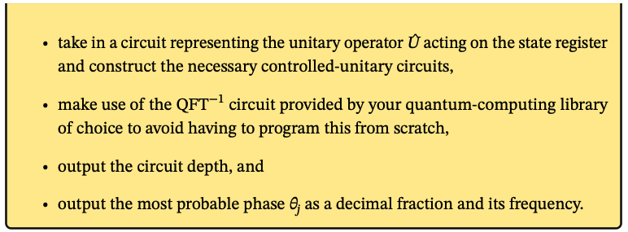

```python
Image('4_1b.png')
```

```python
def build_qpe(U,n):
    M= U.num_qubits
    est= QuantumRegister(n, "est")
    state= QuantumRegister(M, "state")
    c= ClassicalRegister(n, "c")
    qc= QuantumCircuit(state, est, c)

    qc.h(est)
    # hadamards to estimation register
    Ug = U.to_gate(label="U")
    for m in range(n):
        Upow = Ug.power(2**m).control(1)
        #1 control qubit
        qc.append(Upow, [est[m]] + list(state))
        #[control, state[0],..., state[M-1]]

    qc.append(QFTGate(n).inverse(), est)
    qc.measure(est, c)
    return qc

backend=AerSimulator()
def run_qpe(U, n, prep_state, shots,num_theta=3,draw_circuit=False,print_=False):
    M= U.num_qubits
    qc= build_qpe(U, n)

    prep = QuantumCircuit(n + M, n)
    #n+M qubits, n classical bits
    prep.compose(prep_state, qubits=list(range(0,M)), inplace=True)
    # state register first
    qc = prep.compose(qc)
    if draw_circuit:
        print(qc.draw(output="text"))

    transp = transpile(qc,backend)

    t0 = time.perf_counter()

    counts = backend.run(transp, shots=shots).result().get_counts()

    time_taken = time.perf_counter() - t0

# commented out block was used initially finding the most frequent bit string, but IV.3(a)(i)
# motivated finding the three most frequent bit strings

#    count, bitstr = max((c, b) for b, c in counts.items())
#    freq = count / shots
#    #bitstring with biggest count
#    theta = int(bitstr.replace(" ", ""), 2) / (2**n)


    top = sorted(counts.items(), key=lambda x: x[1], reverse=True)[:num_theta] #sort by freq

    thetas = []
    freqs = []
    for bitstr, count in top:
        thetas.append(int(bitstr.replace(" ", ""), 2) / (2**n))#base 2
        freqs.append(count / shots)



    if print_:
        print("Transpiled circuit depth:", transp.depth())
        print("Time taken (s):", time_taken)
        print("Most probable theta:", thetas[0])
        print("Frequency:", freqs[0])

    return qc, counts, transp.depth(), time_taken,thetas
```

Does this produce the same result as the handwritten result for $\theta_j=0.5$?

```python
theta_true = 1/2
U = QuantumCircuit(1)
U.p(2*np.pi*theta_true, 0)

prep = QuantumCircuit(1)
#P|1>=e^(i phi) |1>
prep.x(0)

run_qpe(U, n=3, prep_state=prep, shots=10000,draw_circuit=True,print_=True)
```

```
     ┌───┐┌────────────────┐┌────────────────┐┌────────────────┐              »
q_0: ┤ X ├┤ circuit-1643^1 ├┤ circuit-1643^2 ├┤ circuit-1643^4 ├──────────────»
     ├───┤└───────┬────────┘└───────┬────────┘└───────┬────────┘┌─────────┐┌─┐»
q_1: ┤ H ├────────■─────────────────┼─────────────────┼─────────┤0        ├┤M├»
     ├───┤                          │                 │         │         │└╥┘»
q_2: ┤ H ├──────────────────────────■─────────────────┼─────────┤1 qft_dg ├─╫─»
     ├───┤                                            │         │         │ ║ »
q_3: ┤ H ├────────────────────────────────────────────■─────────┤2        ├─╫─»
     └───┘                                                      └─────────┘ ║ »
c: 3/═══════════════════════════════════════════════════════════════════════╩═»
                                                                            0 »
«
«q_0: ──────
«
«q_1: ──────
«     ┌─┐
«q_2: ┤M├───
«     └╥┘┌─┐
«q_3: ─╫─┤M├
«      ║ └╥┘
«c: 3/═╩══╩═
«      1  2
Transpiled circuit depth: 7
Time taken (s): 0.00277758299995412
Most probable theta: 0.5
Frequency: 1.0
```

```
(<qiskit.circuit.quantumcircuit.QuantumCircuit at 0x321eb0680>,
 {'100': 10000},
 7,
 0.00277758299995412,
 [0.5])
```

The agreement is good, and the circuit looks as expected

Now consider $\theta_j=\frac{3}{8}$.

```python
theta_true = 3/8
U = QuantumCircuit(1)
U.p(2*np.pi*theta_true, 0)

prep = QuantumCircuit(1)
#P|1>=e^(i phi) |1>
prep.x(0)

run_qpe(U, n=3, prep_state=prep, shots=10000,draw_circuit=True,print_=True)
```

```
     ┌───┐┌────────────────┐┌────────────────┐┌────────────────┐              »
q_0: ┤ X ├┤ circuit-1660^1 ├┤ circuit-1660^2 ├┤ circuit-1660^4 ├──────────────»
     ├───┤└───────┬────────┘└───────┬────────┘└───────┬────────┘┌─────────┐┌─┐»
q_1: ┤ H ├────────■─────────────────┼─────────────────┼─────────┤0        ├┤M├»
     ├───┤                          │                 │         │         │└╥┘»
q_2: ┤ H ├──────────────────────────■─────────────────┼─────────┤1 qft_dg ├─╫─»
     ├───┤                                            │         │         │ ║ »
q_3: ┤ H ├────────────────────────────────────────────■─────────┤2        ├─╫─»
     └───┘                                                      └─────────┘ ║ »
c: 3/═══════════════════════════════════════════════════════════════════════╩═»
                                                                            0 »
«
«q_0: ──────
«
«q_1: ──────
«     ┌─┐
«q_2: ┤M├───
«     └╥┘┌─┐
«q_3: ─╫─┤M├
«      ║ └╥┘
«c: 3/═╩══╩═
«      1  2
Transpiled circuit depth: 16
Time taken (s): 0.003332915999976649
Most probable theta: 0.375
Frequency: 1.0
```

```
(<qiskit.circuit.quantumcircuit.QuantumCircuit at 0x321eb28e0>,
 {'011': 10000},
 16,
 0.003332915999976649,
 [0.375])
```

Good agreement.

#### Hamiltonian eigenvalues from quantum phase estimation

When QPE is applied to $\hat U(t)=e^{-it\hat H}$, an eigenstate $\Psi_j$ gives an eigenvalue phase $$ e^{-itE_j}=e^{2\pi i\theta_j},\qquad \theta_j\in[0,1). $$ Phases are defined modulo $2\pi$, so the energy is only determined up to an integer branch, $$ E_j=-\frac{2\pi}{t}\,(\theta_j+m),\qquad m\in\mathbb Z^{0+}, t\in\mathbb R^+, $$ with $m$ restricted to non-negative integers and $t>0$ to ensure $E_j \le 0$. To obtain a unique $E_j$, choose energy bounds $E_{j,\min}\le E_j<E_{j,\max}$ and set $t$ so that each branch interval $$ -\frac{2\pi(m+1)}{t}\le E_j<-\frac{2\pi m}{t} $$ has width equal to the allowed energy range, $$ \frac{2\pi}{t}=E_{j,\max}-E_{j,\min}. $$ Then, provided the true energy lies within the chosen bounds, each measured $\theta_j$ corresponds to a unique integer $m$, and hence to a unique $E_j$ in $[E_{j,\min},E_{j,\max})$ [1].

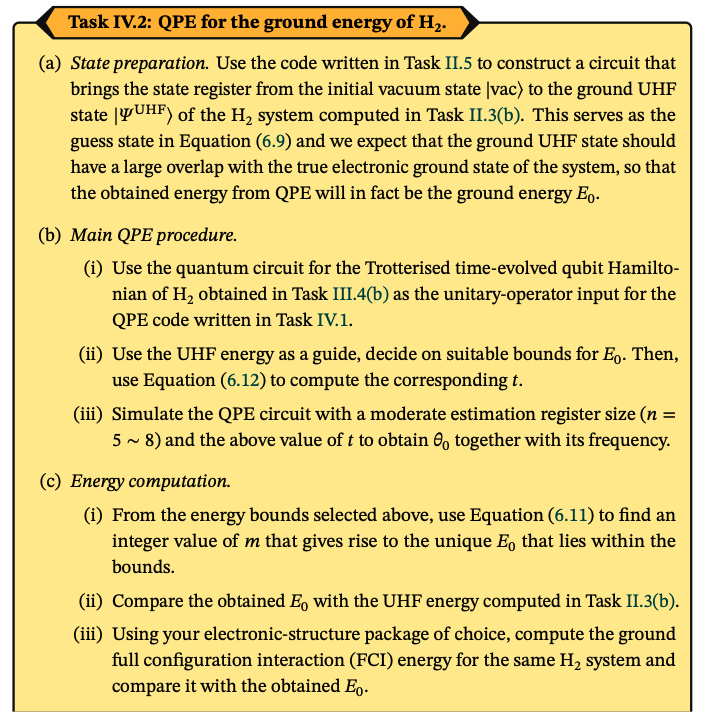

```python
Image('4_2a.png')
```

**(a)**

The occupied orbitals are taken from II.3(b).

```python
atom = """
H 0 0 0
H 0 0 1
"""
C_a, C_b, labels, (occ_a, occ_b),E_uhf = uhf_mos(atom, "sto-3g")
print("Occupied alpha sites =", occ_a)
print("Occupied beta sites =", occ_b)
```

```
Occupied alpha sites = [1. 0.]
Occupied beta sites = [1. 0.]
```

```python
k_uhf = (1, 1, 0, 0)
ps = occupation_to_paulistring(k_uhf)
prep_state = QuantumCircuit(4)
append_pauli(prep_state, ps)

print(prep_state)
```

```
     ┌───┐
q_0: ┤ X ├
     ├───┤
q_1: ┤ X ├
     └───┘
q_2: ─────

q_3: ─────
```

Produces $|0011\rangle$, as desired.

**(b)**

**(ii)**

Picking suitable energy bounds is highly non-trivial. One practical choice is to use the Hartree-Fock energy as an upper bound. Since Hartree-Fock minimizes the energy within a restricted variational space, the variational principle ensures that $E_{\text{HF}}$ is an upper bound to the exact ground-state energy of the Hamiltonian [9]. In the same finite orbital basis, full configuration interaction (FCI) gives the exact ground-state energy of the Hamiltonian in that basis, so $E_0 = E_{\text{FCI}} \le E_{\text{HF}}$ [10]. To allow for small numerical error and make sure that the true energy lies within the interval, $E_{\min}$ is taken as $1.001E_{\text{FCI}}$.

Note that all energies are in Hartree, $E_{\text h}$, with numerical value $4.359 744 722 2060 \times 10^{-18}$J [11].

```python
print("UHF total energy =", E_uhf, "Hartree")
Emax=E_uhf
```

```
UHF total energy = -1.0661086493179366 Hartree
```

The full configuration interaction energy is calculated below [12]. Note that the unrestricted Hartree-Fock energy will be used for the rest of the notebook.

```python
mol = gto.M(atom=atom, basis=basis,unit="Angstrom",charge=0,spin=0,verbose=0)
mf = scf.UHF(mol).run() #unrestricted works

cisolver = fci.FCI(mol, mf.mo_coeff)
EFCI=cisolver.kernel()[0]
Emin=1.001*EFCI

print("FCI energy =", EFCI, "Hartree")
```

```
FCI energy = -1.1011503302326187 Hartree
```

$t$ can now be found with $E_\text{max}=E_\text{HF}$ and $E_\text{min}=1.001*E_{\text{FCI}}$.

```python
t=2*np.pi/(Emax-Emin)
print("t =", t)
```

```
t = 173.84319630642253
```

**(i)**

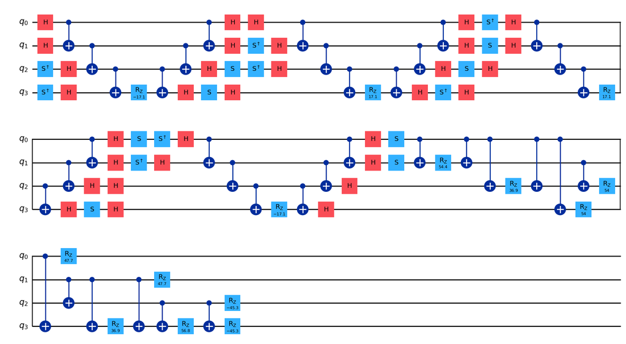

```python
r=1
num_qubits = 4

U_1 = trotter_first_order(H2_q, t, r, num_qubits)
U_1.draw("mpl")
```

**(iii)**

```python
qc_qpe, counts, depth, time_taken,thetas = run_qpe(U_1, n=8, prep_state=prep_state, shots=10000, draw_circuit=True,print_=True)
```

```
      ┌───┐┌────────────────────┐┌────────────────────┐┌────────────────────┐»
 q_0: ┤ X ├┤0                   ├┤0                   ├┤0                   ├»
      ├───┤│                    ││                    ││                    │»
 q_1: ┤ X ├┤1                   ├┤1                   ├┤1                   ├»
      └───┘│  circuit-2117163^1 ││  circuit-2117163^2 ││  circuit-2117163^4 │»
 q_2: ─────┤2                   ├┤2                   ├┤2                   ├»
           │                    ││                    ││                    │»
 q_3: ─────┤3                   ├┤3                   ├┤3                   ├»
      ┌───┐└─────────┬──────────┘└─────────┬──────────┘└─────────┬──────────┘»
 q_4: ┤ H ├──────────■─────────────────────┼─────────────────────┼───────────»
      ├───┤                                │                     │           »
 q_5: ┤ H ├────────────────────────────────■─────────────────────┼───────────»
      ├───┤                                                      │           »
 q_6: ┤ H ├──────────────────────────────────────────────────────■───────────»
      ├───┤                                                                  »
 q_7: ┤ H ├──────────────────────────────────────────────────────────────────»
      ├───┤                                                                  »
 q_8: ┤ H ├──────────────────────────────────────────────────────────────────»
      ├───┤                                                                  »
 q_9: ┤ H ├──────────────────────────────────────────────────────────────────»
      ├───┤                                                                  »
q_10: ┤ H ├──────────────────────────────────────────────────────────────────»
      ├───┤                                                                  »
q_11: ┤ H ├──────────────────────────────────────────────────────────────────»
      └───┘                                                                  »
 c: 8/═══════════════════════════════════════════════════════════════════════»
                                                                             »
«      ┌────────────────────┐┌─────────────────────┐┌─────────────────────┐»
« q_0: ┤0                   ├┤0                    ├┤0                    ├»
«      │                    ││                     ││                     │»
« q_1: ┤1                   ├┤1                    ├┤1                    ├»
«      │  circuit-2117163^8 ││  circuit-2117163^16 ││  circuit-2117163^32 │»
« q_2: ┤2                   ├┤2                    ├┤2                    ├»
«      │                    ││                     ││                     │»
« q_3: ┤3                   ├┤3                    ├┤3                    ├»
«      └─────────┬──────────┘└──────────┬──────────┘└──────────┬──────────┘»
« q_4: ──────────┼──────────────────────┼──────────────────────┼───────────»
«                │                      │                      │           »
« q_5: ──────────┼──────────────────────┼──────────────────────┼───────────»
«                │                      │                      │           »
```

[output cut: 57 more lines]

```
«      ┌─┐
« q_8: ┤M├─────────
«      └╥┘┌─┐
« q_9: ─╫─┤M├──────
«       ║ └╥┘┌─┐
«q_10: ─╫──╫─┤M├───
«       ║  ║ └╥┘┌─┐
«q_11: ─╫──╫──╫─┤M├
«       ║  ║  ║ └╥┘
« c: 8/═╩══╩══╩══╩═
«       4  5  6  7
Transpiled circuit depth: 3647
Time taken (s): 0.051289541999949506
Most probable theta: 0.9296875
Frequency: 0.9609
```

```python
print("Most common bitstring:", max(counts, key=counts.get))
```

```
Most common bitstring: 11101110
```

**(c)**

**(i)**

Code that finds $E_\text{QPE}$ automatically is useful for the next tasks.

```python
def find_E(theta, Emin,Emax):
    t=2*np.pi / (Emax - Emin)
    mlow= int(np.ceil(((-Emax) * t / (2*np.pi)) - theta))
    mhigh = int(np.floor(((-Emin) * t / (2*np.pi)) - theta))
    if mlow != mhigh:
        raise ValueError("Change bounds")
    m=mhigh
    E = -(2*np.pi / t) * (theta + m)
    return E, m
EQPE,m=find_E(thetas[0],Emin,Emax)
print("m =",m)
print("EQPE =",EQPE, "Hartree")
```

```
m = 29
EQPE = -1.0817436445255293 Hartree
```

**(ii)**

```python
print("Hartree-Fock energy is",E_uhf, "Hartree")
```

```
Hartree-Fock energy is -1.0661086493179366 Hartree
```

The $E_\text{QPE}$ value found is lower than the Hartree-Fock energy, as expected for a more accurate approximation to the ground-state energy.

**(iii)**

```python
print("FCI energy =", EFCI, "Hartree")
```

```
FCI energy = -1.1011503302326187 Hartree
```

The FCI energy is still lower, so using second order Trotterisation is one possible way to improve the estimate.

```python
U_2 = trotter_second_order(H2_q, t, r, num_qubits)
qc_qpe, counts, depth, time_taken,thetas = run_qpe(U_2, n=8, prep_state=prep_state, shots=10000, draw_circuit=True,print_=True)
```

```
      ┌───┐┌────────────────────┐┌────────────────────┐┌────────────────────┐»
 q_0: ┤ X ├┤0                   ├┤0                   ├┤0                   ├»
      ├───┤│                    ││                    ││                    │»
 q_1: ┤ X ├┤1                   ├┤1                   ├┤1                   ├»
      └───┘│  circuit-2119638^1 ││  circuit-2119638^2 ││  circuit-2119638^4 │»
 q_2: ─────┤2                   ├┤2                   ├┤2                   ├»
           │                    ││                    ││                    │»
 q_3: ─────┤3                   ├┤3                   ├┤3                   ├»
      ┌───┐└─────────┬──────────┘└─────────┬──────────┘└─────────┬──────────┘»
 q_4: ┤ H ├──────────■─────────────────────┼─────────────────────┼───────────»
      ├───┤                                │                     │           »
 q_5: ┤ H ├────────────────────────────────■─────────────────────┼───────────»
      ├───┤                                                      │           »
 q_6: ┤ H ├──────────────────────────────────────────────────────■───────────»
      ├───┤                                                                  »
 q_7: ┤ H ├──────────────────────────────────────────────────────────────────»
      ├───┤                                                                  »
 q_8: ┤ H ├──────────────────────────────────────────────────────────────────»
      ├───┤                                                                  »
 q_9: ┤ H ├──────────────────────────────────────────────────────────────────»
      ├───┤                                                                  »
q_10: ┤ H ├──────────────────────────────────────────────────────────────────»
      ├───┤                                                                  »
q_11: ┤ H ├──────────────────────────────────────────────────────────────────»
      └───┘                                                                  »
 c: 8/═══════════════════════════════════════════════════════════════════════»
                                                                             »
«      ┌────────────────────┐┌─────────────────────┐┌─────────────────────┐»
« q_0: ┤0                   ├┤0                    ├┤0                    ├»
«      │                    ││                     ││                     │»
« q_1: ┤1                   ├┤1                    ├┤1                    ├»
«      │  circuit-2119638^8 ││  circuit-2119638^16 ││  circuit-2119638^32 │»
« q_2: ┤2                   ├┤2                    ├┤2                    ├»
«      │                    ││                     ││                     │»
« q_3: ┤3                   ├┤3                    ├┤3                    ├»
«      └─────────┬──────────┘└──────────┬──────────┘└──────────┬──────────┘»
« q_4: ──────────┼──────────────────────┼──────────────────────┼───────────»
«                │                      │                      │           »
« q_5: ──────────┼──────────────────────┼──────────────────────┼───────────»
«                │                      │                      │           »
```

[output cut: 57 more lines]

```
«      ┌─┐
« q_8: ┤M├─────────
«      └╥┘┌─┐
« q_9: ─╫─┤M├──────
«       ║ └╥┘┌─┐
«q_10: ─╫──╫─┤M├───
«       ║  ║ └╥┘┌─┐
«q_11: ─╫──╫──╫─┤M├
«       ║  ║  ║ └╥┘
« c: 8/═╩══╩══╩══╩═
«       4  5  6  7
Transpiled circuit depth: 3647
Time taken (s): 0.04731866700012688
Most probable theta: 0.328125
Frequency: 0.9941
```

```python
EQPE,m=find_E(thetas[0],Emin,Emax)
print("m =",m)
print("EQPE =",EQPE, "Hartree")
```

```
m = 30
EQPE = -1.0961443038496748 Hartree
```

An improvement is observed. This is somewhat idealized since the calculation uses a noise-free simulator. On real quantum hardware, the increased circuit depth would generally introduce more noise. The printed depths of the two QPE circuits are identical here because the time evolution unitaries are treated as single gates in this construction. The depth difference between the first order and second order time evolution circuits used to construct $U$ is shown below.

```python
print("First order depth:",U_1.depth())
print("Second order depth:",U_2.depth())
```

```
First order depth: 57
Second order depth: 114
```

**(d)**

**(i)**

Included above.

**(ii)**

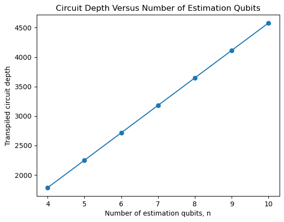

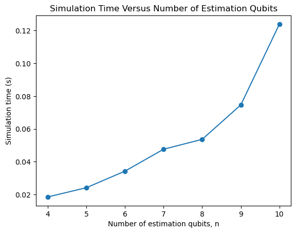

```python
depths = []
times = []

n_list = list(range(4, 11))

for n in n_list:
    mult_run_time=[]
    for r in range(100):#take the average time over many runs to reduce timing noise
        qc_qpe, counts, depth, time_taken,thetas = run_qpe(U_1, n=n, prep_state=prep_state, shots=10000, draw_circuit=False)
        mult_run_time.append(time_taken)
    depths.append(depth)
    times.append(np.mean(mult_run_time))

plt.figure()
plt.plot(n_list, depths, marker="o")
plt.xlabel("Number of estimation qubits, n")
plt.ylabel("Transpiled circuit depth")
plt.title("Circuit Depth Versus Number of Estimation Qubits")
plt.show()

plt.figure()
plt.plot(n_list, times, marker="o")
plt.xlabel("Number of estimation qubits, n")
plt.ylabel("Simulation time (s)")
plt.title("Simulation Time Versus Number of Estimation Qubits")
plt.show()
```

Circuit depth increases approximately linearly with $n$. Simulation time also increases with $n$, but more rapidly. This is broadly because a statevector simulation of $N$ qubits stores $2^N$ amplitudes, so the memory and computational cost grow exponentially with the total qubit number.

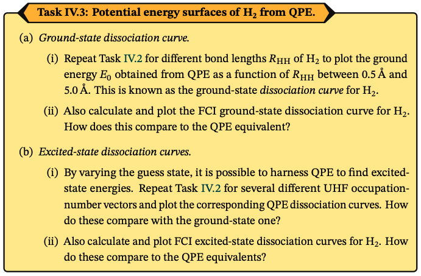

```python
Image('4_3.png')
```

**(a)**

First compare the $H_2$ Hamiltonian from the written functions with the PySCF values for extreme $R_{HH}$ values.

```python
atom = """
H 0 0 0
H 0 0 0.5
"""
print("0.5 Angstrom")
H = second_quantized_hamiltonian(atom=atom, basis="sto-3g")
H_q = jw_transform(H)
print("Written\n")
print(H_q)
mol = MolecularData(atom, basis, multiplicity=1)
mol = run_pyscf(mol)

H_ref = jordan_wigner(mol.get_molecular_hamiltonian())
print("\nPySCF\n")
print(H_ref)
```

```
0.5 Angstrom
Written

(0.3798313517809502+0j) [] +
(-0.04221755692243371+0j) [X0 X1 Y2 Y3] +
(0.04221755692243371+0j) [X0 Y1 Y2 X3] +
(0.04221755692243371+0j) [Y0 X1 X2 Y3] +
(-0.04221755692243371+0j) [Y0 Y1 X2 X3] +
(0.21393531024521223+0j) [Z0] +
(0.17992650976405983+0j) [Z0 Z1] +
(0.13459240346368884+0j) [Z0 Z2] +
(0.1768099603861225+0j) [Z0 Z3] +
(0.21393531024521223+0j) [Z1] +
(0.1768099603861225+0j) [Z1 Z2] +
(0.13459240346368884+0j) [Z1 Z3] +
(-0.3691443152437638+0j) [Z2] +
(0.1862098425924703+0j) [Z2 Z3] +
(-0.36914431524376384+0j) [Z3]

PySCF

0.3798313517809503 [] +
-0.042217556922433716 [X0 X1 Y2 Y3] +
0.042217556922433716 [X0 Y1 Y2 X3] +
0.042217556922433716 [Y0 X1 X2 Y3] +
-0.042217556922433716 [Y0 Y1 X2 X3] +
0.21393531024521256 [Z0] +
0.1799265097640598 [Z0 Z1] +
0.13459240346368873 [Z0 Z2] +
0.17680996038612246 [Z0 Z3] +
0.21393531024521256 [Z1] +
0.17680996038612246 [Z1 Z2] +
0.13459240346368873 [Z1 Z3] +
-0.3691443152437641 [Z2] +
0.18620984259247086 [Z2 Z3] +
-0.3691443152437641 [Z3]
```

```python
atom = """
H 0 0 0
H 0 0 5
"""
print("5 Angstrom")
H = second_quantized_hamiltonian(atom=atom, basis="sto-3g")
H_q = jw_transform(H)
print("Written\n")
print(H_q)
mol = MolecularData(atom, basis, multiplicity=1)
mol = run_pyscf(mol)

H_ref = jordan_wigner(mol.get_molecular_hamiltonian())
print("\nPySCF\n")
print(H_ref)
```

```
5 Angstrom
Written

(-0.5458607027942335+0j) [] +
(-0.08359631370988604+0j) [X0 X1 Y2 Y3] +
(0.08359631370988604+0j) [X0 Y1 Y2 X3] +
(0.08359631370988604+0j) [Y0 X1 X2 Y3] +
(-0.08359631370988604+0j) [Y0 Y1 X2 X3] +
(0.03970104575308903+0j) [Z0] +
(0.11004294256569613+0j) [Z0 Z1] +
(0.026458859479781632+0j) [Z0 Z2] +
(0.11005517318966766+0j) [Z0 Z3] +
(0.039701045753089026+0j) [Z1] +
(0.11005517318966766+0j) [Z1 Z2] +
(0.02645885947978162+0j) [Z1 Z3] +
(0.03957781813360586+0j) [Z2] +
(0.11006740930024875+0j) [Z2 Z3] +
(0.039577818133605724+0j) [Z3]

PySCF

-0.5458607027942334 [] +
-0.08359631370988599 [X0 X1 Y2 Y3] +
0.08359631370988599 [X0 Y1 Y2 X3] +
0.08359631370988599 [Y0 X1 X2 Y3] +
-0.08359631370988599 [Y0 Y1 X2 X3] +
0.039701045753089165 [Z0] +
0.11004294256569604 [Z0 Z1] +
0.02645885947978159 [Z0 Z2] +
0.1100551731896676 [Z0 Z3] +
0.03970104575308918 [Z1] +
0.1100551731896676 [Z1 Z2] +
0.02645885947978159 [Z1 Z3] +
0.03957781813360589 [Z2] +
0.11006740930024869 [Z2 Z3] +
0.03957781813360592 [Z3]
```

Good agreement.

**(i)**

```python
def Ecalc(R, prep, n, basis="sto-3g", shots=200000, r=1, trotter_order=1,num_theta=3):
    #geometry
    atom = f"""
    H 0 0 0
    H 0 0 {R}
    """

    #E UHF
    C_a, C_b, labels, (occ_a, occ_b), E_uhf = uhf_mos(atom, basis)

    #prepare state, generalised for part b
    ps = occupation_to_paulistring(prep)
    prep_state = QuantumCircuit(4)
    append_pauli(prep_state, ps)

    #FCI
    mol = gto.M(atom=atom, basis=basis,unit="Angstrom",charge=0,spin=0,verbose=0)
    mf = scf.UHF(mol).run()

    cisolver = fci.FCI(mol, mf.mo_coeff)
    EFCI=cisolver.kernel()[0]
    # bounds
    Emin = 1.001*EFCI
    Emax = E_uhf
    t = 2*np.pi / (Emax - Emin)

    H = second_quantized_hamiltonian(atom=atom, basis=basis)
    H_q = jw_transform(H)
    H2_q=ps_convert(H_q)

    num_qubits = 4
    if trotter_order == 1:
        U = trotter_first_order(H2_q, t, r, num_qubits)
    else:
        U = trotter_second_order(H2_q, t, r, num_qubits)

    #QPE
    qc_qpe, counts, depth, time_taken,thetas = run_qpe(U, n=n, prep_state=prep_state, shots=shots,num_theta=num_theta, draw_circuit=False)

    # Energies
    energies = [find_E(theta, Emin, Emax)[0] for theta in thetas]
    return energies, EFCI, E_uhf
```

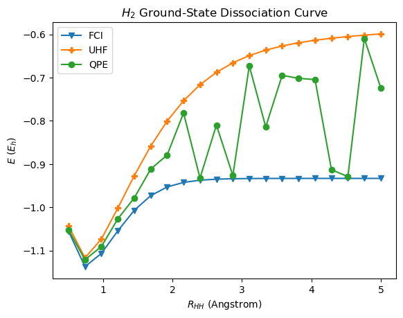

```python
R_list = np.linspace(0.5, 5.0, 20)
k_uhf = (1, 1, 0, 0)
EQPEs = []
FCIs = []
UHFs=[]
for R in R_list:
    energies,FCI,UHF=Ecalc(R,k_uhf, n=8, basis="sto-3g", shots=10000, r=20, trotter_order=2)
    EQPEs.append(energies[0])
    FCIs.append(FCI)
    UHFs.append(UHF)


plt.figure()
plt.plot(R_list, FCIs, marker="v", label="FCI")
plt.plot(R_list, UHFs, marker="P", label="UHF")
plt.plot(R_list, EQPEs, marker="o", label="QPE")
plt.xlabel(r"$R_{HH}$ (Angstrom)")
plt.ylabel(r"$E$ ($E_h$)")
plt.title("$H_2$ Ground-State Dissociation Curve")
plt.legend()
plt.show()
```

HF often provides a good initial guess near equilibrium, but it misses strong correlation at stretched bonds [9]. QPE tends to match FCI more closely at small $R_{HH}$, while the agreement worsens at larger $R_{HH}$. This suggests that the UHF state likely has greater overlap with the true ground state at shorter bond lengths. The jagged line may indicate overlap with excited states at some points, though phase discretization and branch selection may also contribute.

To address this, the code below ranks the three most probable $\theta$ values by energy, identifying the lowest as the ground-state, the second lowest as the first excited-state, and so on. Note that there is no guarantee that these correspond to $E_0$, $E_1$, and $E_2$, and this is only a suggestion.

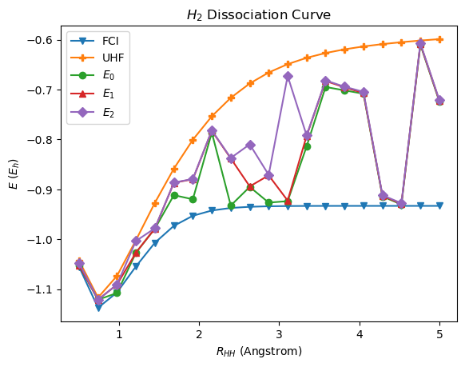

```python
Es0 = []
Es1 = []
Es2 = []

for R in R_list:
    energies,FCI,UHF=Ecalc(R,k_uhf, n=8, basis="sto-3g", shots=10000, r=20, trotter_order=2)
    energies.sort()
    Es0.append(energies[0])
    Es1.append(energies[1])
    Es2.append(energies[2])


plt.figure()
plt.plot(R_list, FCIs, marker="v", label="FCI")
plt.plot(R_list, UHFs, marker="P", label="UHF")
plt.plot(R_list, Es0, marker="o", label=r"$E_0$")
plt.plot(R_list, Es1, marker="^", label=r"$E_1$")
plt.plot(R_list, Es2, marker="D", label=r"$E_2$")

plt.xlabel(r"$R_{HH}$ (Angstrom)")
plt.ylabel(r"$E$ ($E_h$)")
plt.title("$H_2$ Dissociation Curve")
plt.legend()
plt.show()
```

Just considering $E_0$, taken as the lowest energy among the 3 $\theta$ values, is shown below.

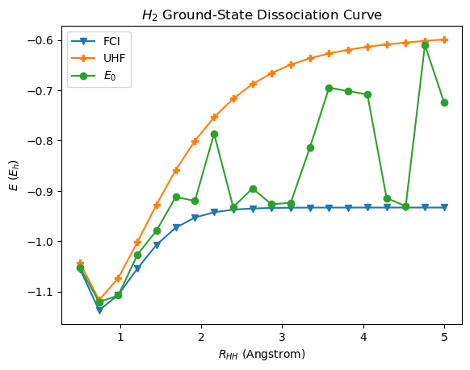

```python
E0s = []

for R in R_list:
    energies,FCI,UHF=Ecalc(R,k_uhf, n=8, basis="sto-3g", shots=10000, r=20, trotter_order=2)
    energies.sort()
    E0s.append(energies[0])


plt.figure()
plt.plot(R_list, FCIs, marker="v", label="FCI")
plt.plot(R_list, UHFs, marker="P", label="UHF")
plt.plot(R_list, E0s, marker="o", label="$E_0$")
plt.xlabel(r"$R_{HH}$ (Angstrom)")
plt.ylabel(r"$E$ ($E_h$)")
plt.title("$H_2$ Ground-State Dissociation Curve")
plt.legend()
plt.show()
```

The results are slightly improved, though more $\theta$ values could also be ranked. Note that using the FCI energy as a bound is somewhat artificial, since it effectively uses knowledge of the answer when reconstructing the QPE energy. Since QPE is not variational, ranking $\theta$ values by energy can in principle produce energies below the true ground-state energy, although the FCI based lower bound used here restricts that possibility. Another issue is that the choice of initial state is crucial, and poor overlap can significantly affect the result. Even so, QPE does recover energies close to FCI at certain separations. These results show that the choice of energy bounds matters and is not straightforward.

$E_0$, taken as the lowest energy among the 20 $\theta$ values, is shown below.

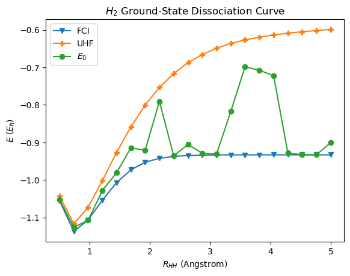

```python
E0s = []

for R in R_list:
    energies,FCI,UHF=Ecalc(R,k_uhf, n=8, basis="sto-3g", shots=10000, r=20, trotter_order=2,num_theta=20)
    energies.sort()
    E0s.append(energies[0])


plt.figure()
plt.plot(R_list, FCIs, marker="v", label="FCI")
plt.plot(R_list, UHFs, marker="P", label="UHF")
plt.plot(R_list, E0s, marker="o", label="$E_0$")
plt.xlabel(r"$R_{HH}$ (Angstrom)")
plt.ylabel(r"$E$ ($E_h$)")
plt.title("$H_2$ Ground-State Dissociation Curve")
plt.legend()
plt.show()
```

A further improvement is seen, though some points may still reflect overlap with excited states. There are many other reasons why the energies do not follow a smooth curve along the FCI line, including finite estimation precision and Trotter error.

**(b)**

From the ground-state analysis, it appears that reconstructed QPE energies associated with excited-state overlap can lie between the FCI and HF ground-state energies, so the same bounds are kept for the other initial state guesses.

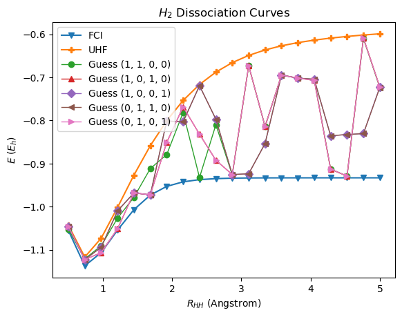

```python
occ_list = [(1,1,0,0),(1,0,1,0),(1,0,0,1),(0,1,1,0),(0,1,0,1)]
markers = ["o", "^", "D", "<", ">"]
curves = {}
for occ in occ_list:
    EQPEs = []
    for R in R_list:
        energies,FCI,UHF=Ecalc(R,occ, n=8, basis="sto-3g", shots=10000, r=20, trotter_order=2)
        EQPEs.append(energies[0])

    curves[occ] = EQPEs

plt.figure()

plt.plot(R_list, FCIs, marker="v", label="FCI")
plt.plot(R_list, UHFs, marker="P", label="UHF")

for i, occ in enumerate(occ_list):
    plt.plot(R_list, curves[occ], marker=markers[i],linewidth=1, label=f"Guess {occ}")

plt.xlabel(r"$R_{HH}$ (Angstrom)")
plt.ylabel(r"$E$ ($E_h$)")
plt.title("$H_2$ Dissociation Curves")
plt.legend()
plt.show()
```

To compare the different initial-state guesses more clearly, the reconstructed QPE energies are ranked by energy at each $R_{HH}$. These are labeled $E_0,\dots,E_4$ for convenience, where $E_0$ is the lowest and $E_4$ the highest. For clarity, only $E_0$ and $E_4$ are shown.

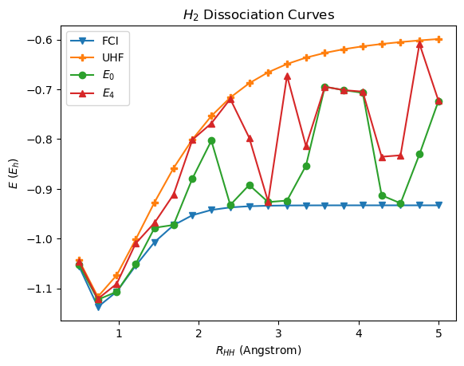

```python
E0 = []
E4 = []

for j in range(len(R_list)):
    vals = [curves[occ][j] for occ in occ_list]
    vals.sort()
    E0.append(vals[0])
    E4.append(vals[4])

plt.figure()
plt.plot(R_list, FCIs, marker="v", label="FCI")
plt.plot(R_list, UHFs, marker="P", label="UHF")
plt.plot(R_list, E0, marker="o", label=r"$E_0$")
plt.plot(R_list, E4, marker="^", label=r"$E_4$")

plt.xlabel(r"$R_{HH}$ (Angstrom)")
plt.ylabel(r"$E$ ($E_h$)")
plt.title("$H_2$ Dissociation Curves")
plt.legend()
plt.show()
```

There is agreement at some points, but overall the disagreement shows how important the choice of initial state is.

## Module 4 Logbook

This lab focused on obtaining electronic energies using quantum phase estimation. Since the electronic Hamiltonian $\hat H$ is Hermitian but not unitary, the unitary time evolution operator $U(t)=\exp(-it\hat H)$ can be simulated on a quantum computer. Acting on an energy eigenstate $\Psi_j$, this produces a phase $e^{-itE_j}$, so QPE can be used to estimate a phase $\theta$ with $e^{2\pi i\theta}=e^{-itE_j}$, from which the energy can be reconstructed once $t$ and suitable energy bounds are chosen. The QPE circuit was implemented and tested by taking the most probable measured bitstrings and converting the corresponding phases into energy estimates.

A simple one qubit phase gate example was first used to validate the implementation, confirming that exact $n$-bit phases are recovered correctly. QPE was then applied to $H_2$, with the state register prepared in the unrestricted Hartree-Fock occupation state as an initial guess for the ground-state. The time evolution operator was implemented using Trotterized circuits from earlier sections, and both first order and second order decompositions were considered.

The measured phases were converted into energies by fixing $t$ from an allowed energy interval and selecting the integer branch $m$ that placed the reconstructed energy inside the chosen bounds. In practice, Hartree Fock and FCI energies were used to define these bounds, although the use of FCI energies makes the reconstruction somewhat artificial.

Finally, QPE dissociation curves for $H_2$ were compared with full configuration interaction and unrestricted Hartree Fock reference curves. The results showed that QPE can recover energies close to FCI at some bond lengths, but the agreement worsens at larger separations. Updated tests also showed that ranking several of the most probable phases can slightly improve the apparent ground state curve, while different initial occupation state guesses can lead to noticeably different reconstructed energies. Overall, the results highlight the importance of the initial state, phase precision, Trotter error, and energy bound selection. Circuit depth and simulation time were also tracked as functions of $n$, showing the rising cost of higher phase precision.

### References

[1] Huynh, Bang. Quantum Computing for Quantum Chemistry. Laboratory manual, University of Oxford, September 2025.

[2] Young, David C. *Computational Chemistry: A Practical Guide for Applying Techniques to Real World Problems*. Wiley Interscience, 2001.

[3] *PySCF: Quickstart*. PySCF.org. https://pyscf.org/quickstart.html.

[4] Schulz, H. *Basis Sets in Quantum Chemistry*. Lecture notes, University of Rostock https://www.schulz.chemie.uni-rostock.de/storages/uni-rostock/Alle_MNF/Chemie_Schulz/Computerchemie_3/basis_sets.pdf.

[5] *OpenFermion-PySCF Demo*. Quantumlib. https://github.com/quantumlib/OpenFermion-PySCF/blob/main/examples/openfermionpyscf_demo.ipynb.

[6] *Superposition with Qiskit*. IBM Quantum Learning. https://quantum.cloud.ibm.com/learning/en/modules/quantum-mechanics/superposition-with-qiskit.

[7] *NumPy Data types*. NumPy Developers Documentation. https://numpy.org/devdocs/user/basics.types.html.

[8] Borchert, Oliver et al. *BGP Secure Routing Extension (BGP-SRx): Reference Implementation and Test Tools for Emerging BGP Security Standards*. NIST Technical Note 2060, National Institute of Standards and Technology, 2021. https://doi.org/10.6028/NIST.TN.2060.

[9] Tew, David P. *TCC Electronic Structure Module: L2 Hartree-Fock Theory*. Lecture notes, University of Oxford, 2021

[10] Tew, David P. *TCC Electronic Structure Module: L3: Configuration Interaction Theory*. Lecture notes, University of Oxford, 2021

[11] Mohr, P. J. et al. *CODATA Recommended Values of the Fundamental Physical Constants: 2022*. NIST Special Publication 961, National Institute of Standards and Technology, May 2024. https://physics.nist.gov/cuu/pdf/wall_2022.pdf

[12] *Configuration Interaction (CI) - User Guide*. PySCF.org. https://pyscf.org/user/ci.html.